# Reproducible Research - Project # 1

Eliot Cordoba

12/28/2020

## **1. Loading and preprocessing the data**

#### 1.1 Load the data

```r
setwd("~/Desktop/Reproducible Research Project 1")
activity <- read.csv("activity.csv")
```

#### 1.2 Process/transform the data

```r
activity <- transform(activity, date = as.Date(date))
```

## **2. What is mean total number of steps taken per day?**

#### 2.1 Calculate the total number of steps taken per day

```r
StepsPerDay <- aggregate(steps ~ date, activity, sum, na.rm = TRUE)
```

#### 2.2 Make a histogram of the total number of steps taken each day

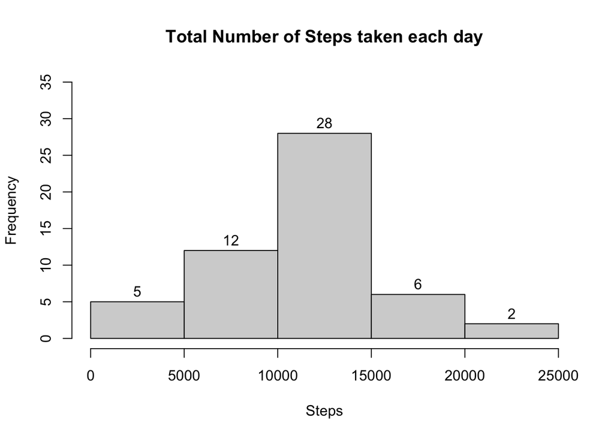

```r
hist(StepsPerDay$steps, xlab = "Steps", main = "Total Number of Steps taken each day", ylim = c(0, 35), labels = TRUE)
```

```r
# Save plot to png file
dev.copy(png, file = "Histogram StepsPerDay.png")
```

```r
dev.off()
```

#### 2.3 Calculate and report the mean and median of the total number of steps taken per day

```r
# Mean:
mean(StepsPerDay$steps)
```

```
## [1] 10766.19
```

```r
# Median:
median(StepsPerDay$steps)
```

```
## [1] 10765
```

## **3. What is the average daily activity pattern?**

#### 3.1 Make a time series plot (i.e. type = “l”) of the 5-minute interval (x-axis) and the average number of steps taken, averaged across all days (y-axis)

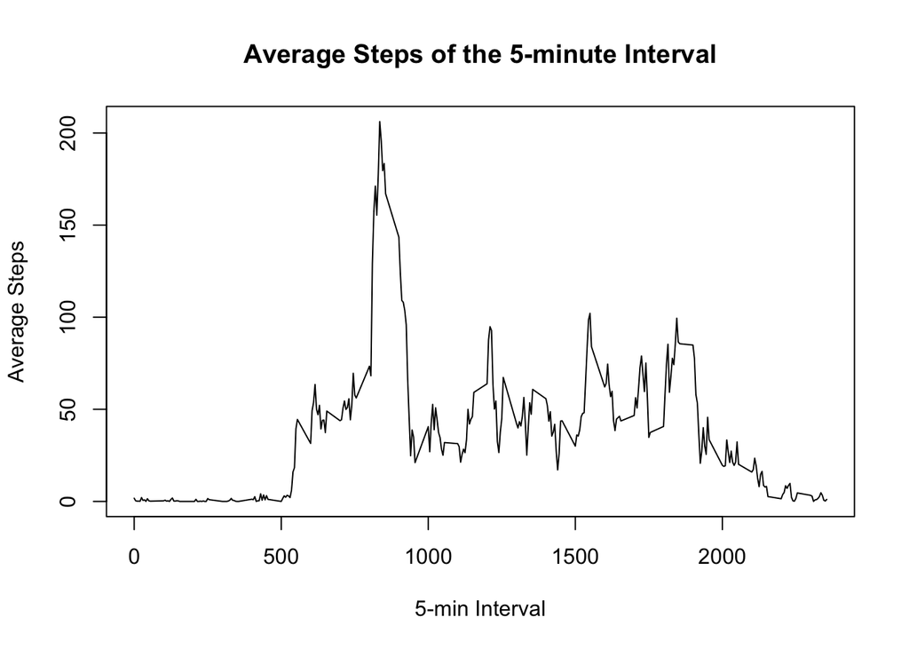

```r
mean_Avg_Daily <- aggregate(steps ~ interval, activity, mean, na.rm = TRUE)
plot(mean_Avg_Daily$interval, mean_Avg_Daily$steps, type = "l", main = "Average Steps of the 5-minute Interval", xlab = "5-min Interval", ylab = "Average Steps")
```

```r
# Save plot to png file
dev.copy(png, file = "Time Series Plot.png")
```

```r
dev.off()
```

#### 3.2 Which 5-minute interval, on average across all the days in the dataset, contains the maximum number of steps?

```r
max_interval <- mean_Avg_Daily$interval[which(mean_Avg_Daily$steps == max(mean_Avg_Daily$steps))]
max_interval
```

```
## [1] 835
```

## **4. Imputing missing values**

#### 4.1 Calculate and report the total number of missing values in the dataset

```r
sum(is.na(activity))
```

```
## [1] 2304
```

#### 4.2 & 4.3 Devise a strategy for filling in all of the missing values in the dataset.

```r
fillIn_MV <- activity
for (i in 1:length(fillIn_MV$steps)) {
  if (is.na(fillIn_MV$steps[i])) {
    fillIn_MV$steps[i] <- mean_Avg_Daily$steps[mean_Avg_Daily$interval == fillIn_MV$interval[i]]
  }
}
# Aggregate filled data + verify if any NA
filled_MisValues <- aggregate(steps ~ date, fillIn_MV, sum, na.rm = TRUE)
sum(is.na(filled_MisValues$steps))
```

```
## [1] 0
```

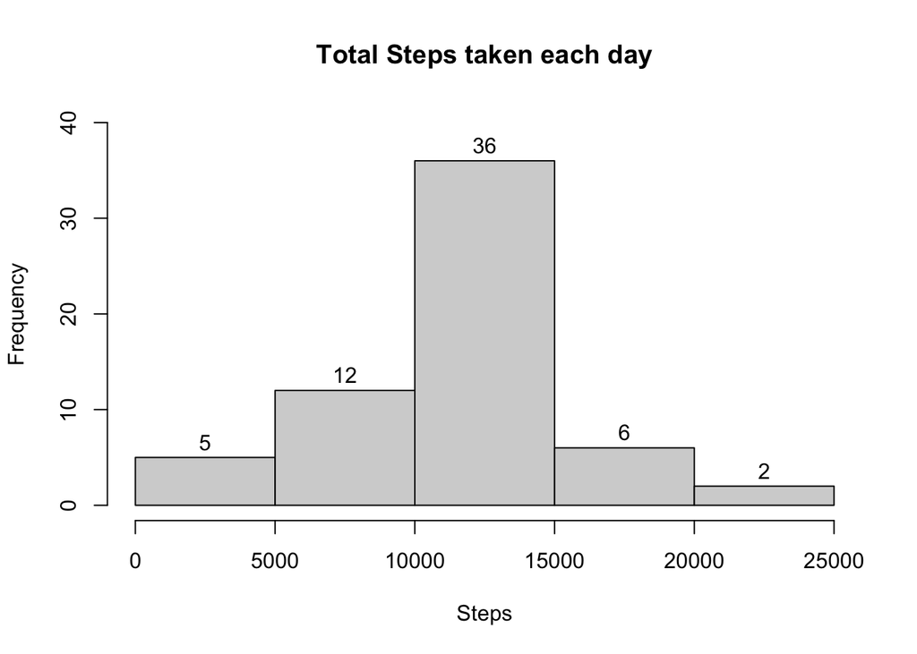

```r
hist(filled_MisValues$steps, main = "Total Steps taken each day", xlab = "Steps", ylim = c(0, 40), labels = TRUE)
```

```r
# Save plot to png file
dev.copy(png, file = "Histogram Total Daily Steps.png")
```

```r
dev.off()
```

```r
# Mean = total steps taken per day
mean(filled_MisValues$steps)
```

```
## [1] 10766.19
```

```r
# Median = total steps taken per day
median(filled_MisValues$steps)
```

```
## [1] 10766.19
```

## **5. Are there differences in activity patterns between weekdays and weekends?**

#### 5.1 Create a new factor variable in the dataset with two levels – “weekday” and “weekend” indicating whether a given date is a weekday or weekend day.

```r
fillIn_MV$date <- as.Date(filled_MisValues$date)
fillIn_MV$wkdy <- "weekday"
fillIn_MV$wkdy[weekdays(fillIn_MV$date) == "Saturday" | weekdays(fillIn_MV$date) == "Sunday"] <- "weekend"
fillIn_MV$wkdy <- as.factor(fillIn_MV$wkdy)
fillIn_MV_Interval <- aggregate(steps ~ interval + wkdy, fillIn_MV, mean, na.rm = TRUE)
```

#### 5.2 Make a panel plot containing a time series plot (i.e. type = “l”) of the 5-minute interval (x-axis) and the average number of steps taken, averaged across all weekday days or weekend days (y-axis).

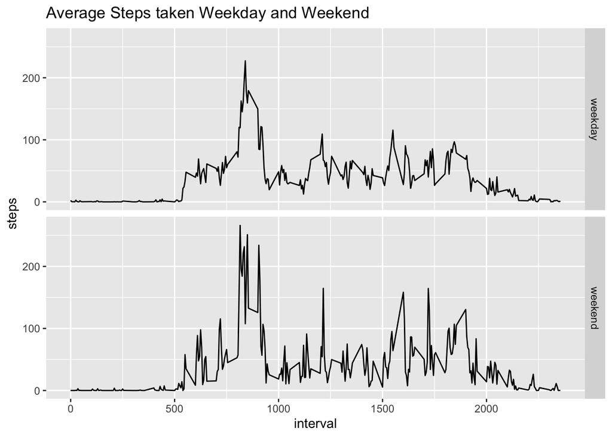

```r
library(ggplot2)
x <- ggplot(fillIn_MV_Interval, aes(interval, steps))
x + facet_grid(wkdy ~ .) + geom_line() + ggtitle("Average Steps taken Weekday and Weekend")
```

```r
# Save plot to png file
dev.copy(png, file = "Panel Plot - Time Series.png")
```

```r
dev.off()
```